# Taller de Repaso y Análisis de Datos en RMarkdown

Crispthofer Rincon

Pacific Task Force

2023-10-17

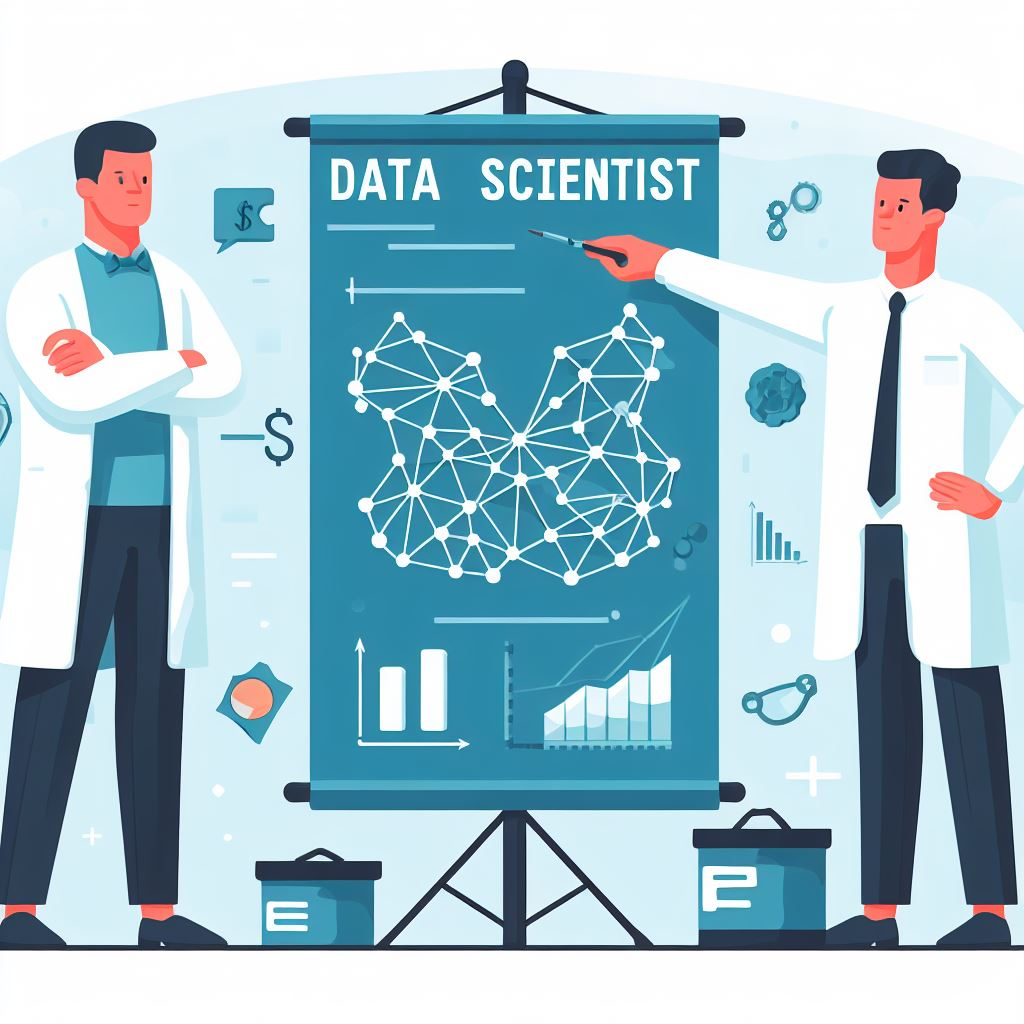

# 1 ¿Quién soy?

Hola, soy Crispthofer Rincon, ingeniero industrial con experiencia en marketing comercial y social, community management y desarrollo de software. En los últimos 6 meses me he enfocado en fortalecer mis habilidades en R y Python para el área de Data Science.

Me apasiona utilizar los datos para resolver problemas y generar un impacto positivo en la sociedad, especialmente en mi región, América Latina y el Caribe.

Soy miembro de la organización social Amafrocol que implementa proyectos en favor de mujeres afrocolombianas y sus familias. Creo que el análisis de datos puede ser una herramienta poderosa para apoyar el desarrollo de estas comunidades.

# 2 Mi familia

## 2.1 Abuelos

- **Luis Rincon**
- **Sofia Arambulo**
- **Samuel Murrain**
- **Ana Mosquera**

## 2.2 Padres

- *Cristobal Rincon Arambulo*
- *Mildred Murrain Mosquera*

## 2.3 Hermanos

- Laura Rincon Murrain
- Alberto Rincon Murrain
- Simon Rincon Murrain
- Cecilia Rincon Murrain

## 2.4 Estadísticas descriptivas

### 2.4.1 Tabla de Edad y Estatura de miembros de mi familia

```
##       nombre edad estatura
## 1      Laura   20     1.50
## 2    Alberto   15     1.90
## 3      Simon   30     1.70
## 4    Cecilia   40     1.80
## 5  Cristobal   70     1.60
## 6       Luis   89     1.70
## 7     Samuel   92     1.65
## 8      Sofia   90     1.75
## 9    Mildred   69     1.82
## 10       Ana   91     1.90
```

### 2.4.2 Variable Edad

```
##    Min. 1st Qu.  Median    Mean 3rd Qu.    Max.
##   15.00   32.50   69.50   60.60   89.75   92.00
```

### 2.4.3 Variable Estatura

```
##    Min. 1st Qu.  Median    Mean 3rd Qu.    Max.
##   1.500   1.663   1.725   1.732   1.815   1.900
```

- Interpretación
  1. El minimo de estatura de los miembros de mi familia es de 1.5 metros
  2. El maximo de estatura de los miembros de mi familia es de 1.9 metros
  3. El 25% de los miembros de mi familia tiene estatura menor a 1.67 metros
  4. El 50% de los miembros de mi familia tiene estatura menor a 1.73 metros
  5. El 75% de los miembros de mi familia tiene estatura menor a 1.82 metros
  6. El promedio de estatura de mi familia es de 1.732 metros
  7. La estatura en la que tiende a centrarse mi familia es es 1.725 metros

## 2.5 Gráficos

### 2.5.1 Histograma de variable Edad

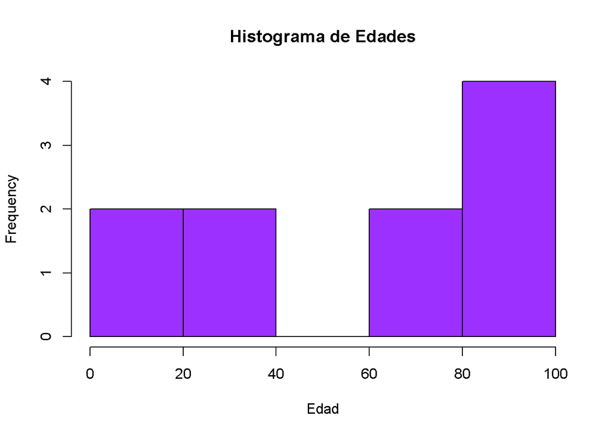

### 2.5.2 Histograma de variable Estatura

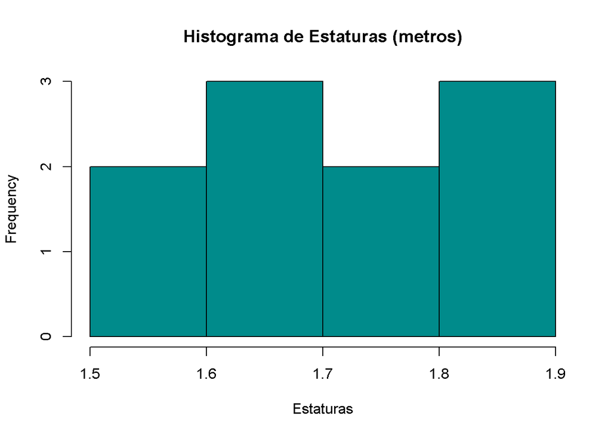

### 2.5.3 Gráfico de dispersión de Edad vs. Estatura

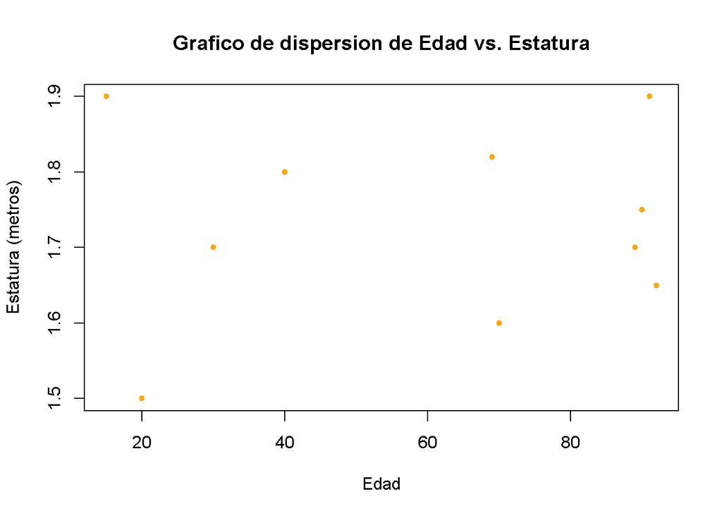